# Data

```r
library(devtools)
load_all("..")
```

```
## Loading fitsir
```

## Ebola

I got the data from [here](https://github.com/cmrivers/ebola). [Here](http://currents.plos.org/outbreaks/article/obk-14-0036-early-epidemic-dynamics-of-the-west-african-2014-ebola-outbreak-estimates-derived-with-a-simple-two-parameter-model/)’s a paper that fitted IDEA model to the data.

```r
eboladf <- read.csv("country_timeseries.csv")
```

I’m going to try to fit curves to ebola epidemic data

```
##           R0            r       infper           i0           I0
## 1.131226e+00 4.833260e-02 2.715068e+00 2.033650e-06 7.647072e-02
##           S0            N
## 3.760263e+04 3.760270e+04
```

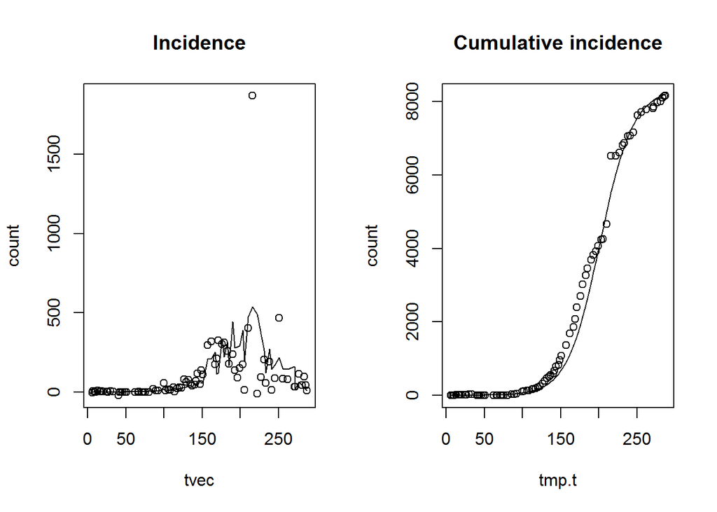

```
##
## Call:
## mle2(minuslogl = g, start = start, method = method, data = c(data,
##     list(debug = debug)), vecpar = TRUE, control = control)
##
## Coefficients:
##    log.beta   log.gamma       log.N     logit.i
##  -0.8755146  -0.9988169  10.5348312 -13.1056765
##
## Log-likelihood: -540.49
```

```r
tmpfun <- function(data = "Liberia",
                   fitfun = fitsir,
                   auto = FALSE,
                   plot.it = FALSE,
                   start.pars = NA){
    case <- paste0("Cases_", data)
    cumInc <- eboladf[,c("Day", case)]
    cumInc <- cumInc[!is.na(cumInc[,2]),]
    cumInc <- cumInc[nrow(cumInc):1,]
    tmp.t <- cumInc[-1,1]
    tmp.I <- diff(cumInc[,2])
    df <- data.frame(tvec = tmp.t, count = tmp.I)
    if(auto){
        start <- startfun(data = df, auto = TRUE, incidence = TRUE)
    }else{
        start <- startfun()
    }
    if(!is.na(start.pars[1])){
        start <- start.pars
    }
    f.i <- fitfun(df, incidence = TRUE, start = start)
    pars <- coef(f.i)
    print(summarize.pars(pars))
    if(plot.it){
        par(mfrow = c(1,2))
        plot(df, main = "Incidence")
        tpars <- trans.pars(pars)
        inc <- SIR.detsim(tmp.t, tpars, incidence = TRUE)
        lines(tmp.t, inc)
        plot(tmp.t, cumsum(df[,2]), main = "Cumulative incidence", ylab = "count")
        lines(tmp.t, cumsum(inc))
        par(mfrow = c(1,1))
    }
    return(f.i)
}

tmpfun(auto = TRUE, plot.it = TRUE)
```

```
##           R0            r       infper           i0           I0
## 1.059536e+00 2.482881e-02 2.397868e+00 2.578920e-05 7.509469e-01
##           S0            N
## 2.911791e+04 2.911866e+04
```

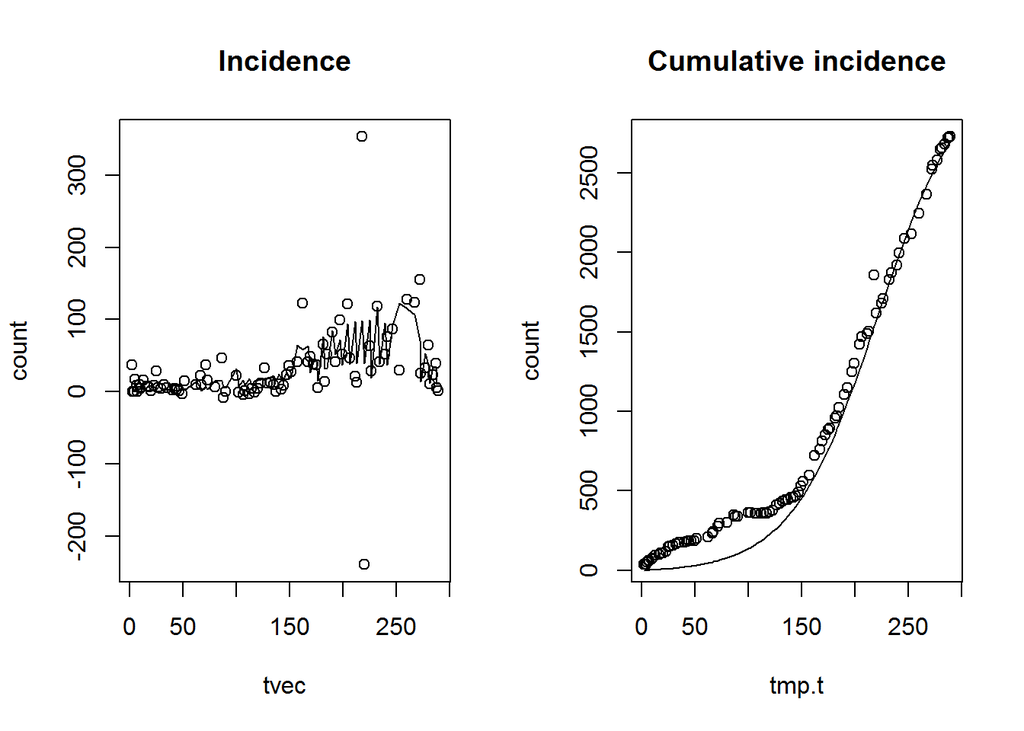

```
##
## Call:
## mle2(minuslogl = g, start = start, method = method, data = c(data,
##     list(debug = debug)), vecpar = TRUE, control = control)
##
## Coefficients:
##    log.beta   log.gamma       log.N     logit.i
##  -0.8167485  -0.8745798  10.2791344 -10.5655289
##
## Log-likelihood: -481.35
```

```r
tmpfun(data = "Guinea", auto = TRUE, plot.it = TRUE)
```

```
##            R0             r        infper            i0            I0
##  3.235098e-07 -6.444818e+03  1.551634e-04  2.398128e-03  6.952491e-05
##            S0             N
##  2.892180e-02  2.899133e-02
```

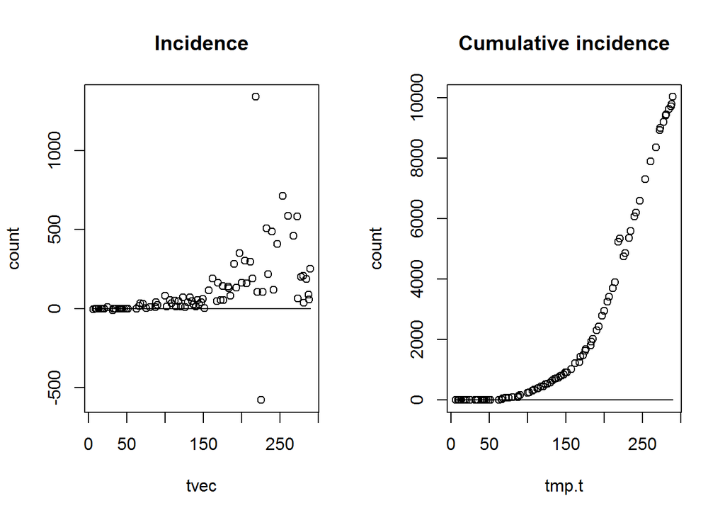

```
##
## Call:
## mle2(minuslogl = g, start = start, method = method, data = c(data,
##     list(debug = debug)), vecpar = TRUE, control = control)
##
## Coefficients:
##  log.beta log.gamma     log.N   logit.i
## -6.173004  8.771032 -3.540759 -6.030666
##
## Log-likelihood: -595
```

```r
tmpfun(data = "SierraLeone", plot.it = TRUE) ##unable to fit...
```

I found this parameter manually:

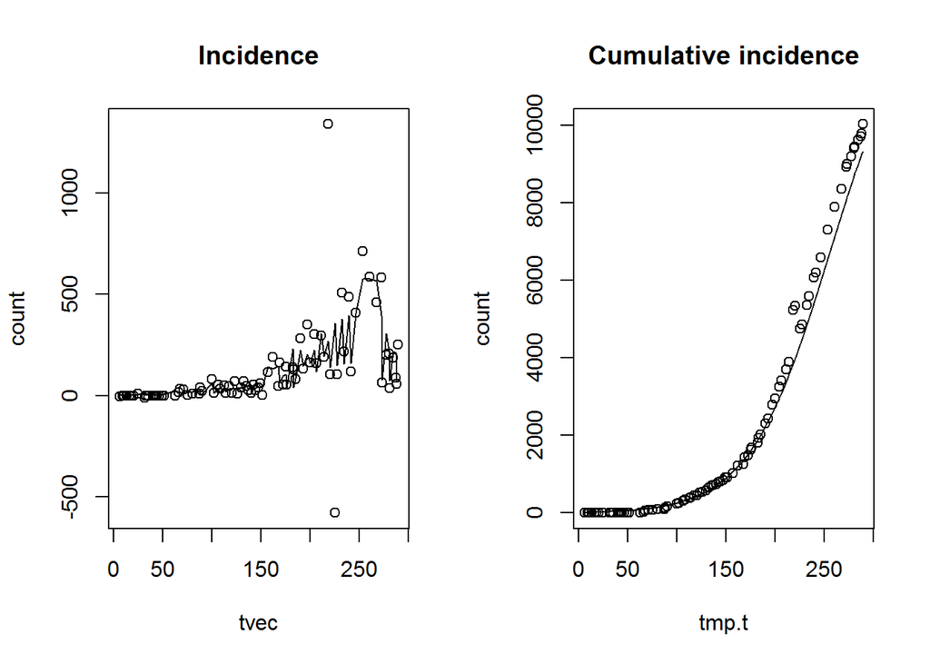

```r
pars.S <- c(log.beta = 0.52, log.gamma = 0.505, log.N = 13, logit.i = -14)
data = "SierraLeone"
case <- paste0("Cases_", data)
cumInc <- eboladf[,c("Day", case)]
cumInc <- cumInc[!is.na(cumInc[,2]),]
cumInc <- cumInc[nrow(cumInc):1,]
tmp.t <- cumInc[-1,1]
tmp.I <- diff(cumInc[,2])
df <- data.frame(tvec = tmp.t, count = tmp.I)
par(mfrow = c(1,2))
plot(df, main = "Incidence")
tpars <- trans.pars(pars.S)
inc <- SIR.detsim(tmp.t, tpars, incidence = TRUE)
lines(tmp.t, inc)
plot(tmp.t, cumsum(df[,2]), main = "Cumulative incidence", ylab = "count")
lines(tmp.t, cumsum(inc))
```

```r
par(mfrow = c(1,1))
```

Cumulative incidence certainly looks great… What happens if we use these to for fitting?

```
##           R0            r       infper           i0           I0
## 1.014420e+00 2.795612e-02 5.158091e-01 4.767723e-07 2.082990e-01
##           S0            N
## 4.368938e+05 4.368940e+05
```

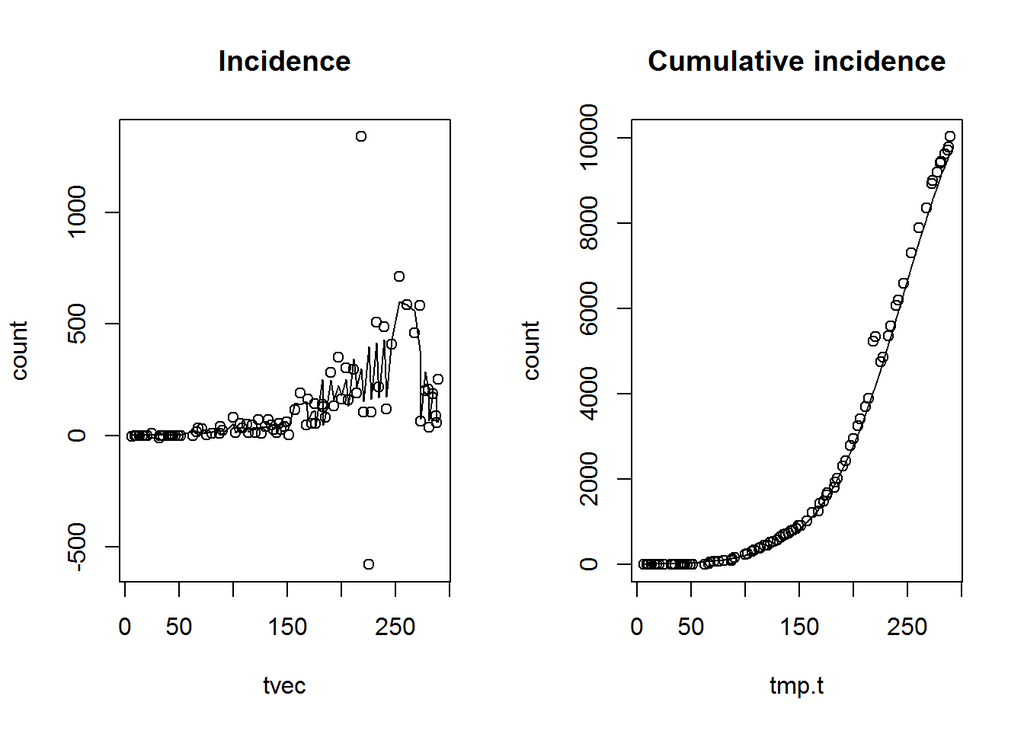

```
##
## Call:
## mle2(minuslogl = g, start = start, method = method, data = c(data,
##     list(debug = debug)), vecpar = TRUE, control = control)
##
## Coefficients:
##    log.beta   log.gamma       log.N     logit.i
##   0.6763355   0.6620185  12.9874459 -14.5562264
##
## Log-likelihood: -559.67
```

```r
tmpfun(data = "SierraLeone", start.pars = pars.S, plot.it = TRUE)
```

This works. I guess we needed a good starting parameter.

## Flu (2009) in WSU

I got the data from here. They use daily reports in other papers but they don’t provide it so I’m just going to try with weekly reports to see if it works…

```r
df.flu <- data.frame(
    tvec = c(1:16),
    count = c(73, 524, 569, 357, 149, 92, 53, 95, 56, 61, 94, 81, 41, 16, 12, 3))
plot(df.flu)
(fit1 <- fitsir(df.flu, incidence = TRUE))
```

```
##
## Call:
## mle2(minuslogl = g, start = start, method = method, data = c(data,
##     list(debug = debug)), vecpar = TRUE, control = control)
##
## Coefficients:
##  log.beta log.gamma     log.N   logit.i
## -3.027922 -1.557275 13.063443 -3.953763
##
## Log-likelihood: -100.29
```

```r
(fit2 <- fitsir.optim(df.flu, incidence = TRUE, nll = TRUE))
```

```
##
## Call:
## mle2(minuslogl = objfun, start = start, method = "BFGS", data = c(data,
##     list(debug = debug)), vecpar = TRUE, gr = gradfun, control = control)
##
## Coefficients:
##   log.beta  log.gamma      log.N    logit.i
##  0.8206636 -0.2843426  7.5935349 -4.0401148
##
## Log-likelihood: -86.17
```

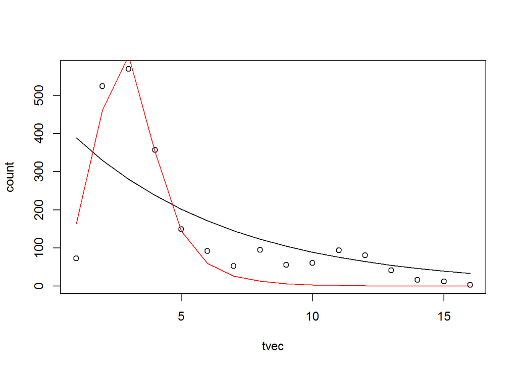

```r
lines(SIR.detsim(df.flu$tvec, trans.pars(coef(fit1)), incidence = TRUE))
lines(SIR.detsim(df.flu$tvec, trans.pars(coef(fit2)), incidence = TRUE), col = 2)
```

```r
summarize.pars(coef(fit1))
```

```
##            R0             r        infper            i0            I0
##  2.297767e-01 -1.622933e-01  4.745872e+00  1.882134e-02  8.872207e+03
##            S0             N
##  4.625186e+05  4.713909e+05
```

```r
summarize.pars(coef(fit2))
```

```
##           R0            r       infper           i0           I0
## 3.019243e+00 1.519498e+00 1.328888e+00 1.729121e-02 3.432856e+01
##           S0            N
## 1.950991e+03 1.985319e+03
```

Data source says that $N$ is 18234. We don’t get any values that are close… It makes sense that we get a bad fit because we’re only given reports at every week. Also, they don’t provide reportings of the new cases through out the whole week. They just give us new cases that were counted on the day.

## R0 package

This package has some public data: https://github.com/cran/R0

```r
library(R0)
data(Germany.1918)
g.inc <- check.incid(Germany.1918)$incid
t.germ <- 1:length(g.inc)
df.1918 <- data.frame(tvec = t.germ, count = g.inc)
(fit.germ1 <- fitsir(df.1918, incidence = TRUE))
```

```
##
## Call:
## mle2(minuslogl = g, start = start, method = method, data = c(data,
##     list(debug = debug)), vecpar = TRUE, control = control)
##
## Coefficients:
##  log.beta log.gamma     log.N   logit.i
## -1.515019 -2.556803  9.114372 -5.013138
##
## Log-likelihood: -505.41
```

```r
(fit.germ2 <- fitsir.optim(df.1918, incidence = TRUE, nll = TRUE))
```

```
##
## Call:
## mle2(minuslogl = objfun, start = start, method = "BFGS", data = c(data,
##     list(debug = debug)), vecpar = TRUE, gr = gradfun, control = control)
##
## Coefficients:
##  log.beta log.gamma     log.N   logit.i
## -1.515059 -2.556828  9.114374 -5.012939
##
## Log-likelihood: -505.41
```

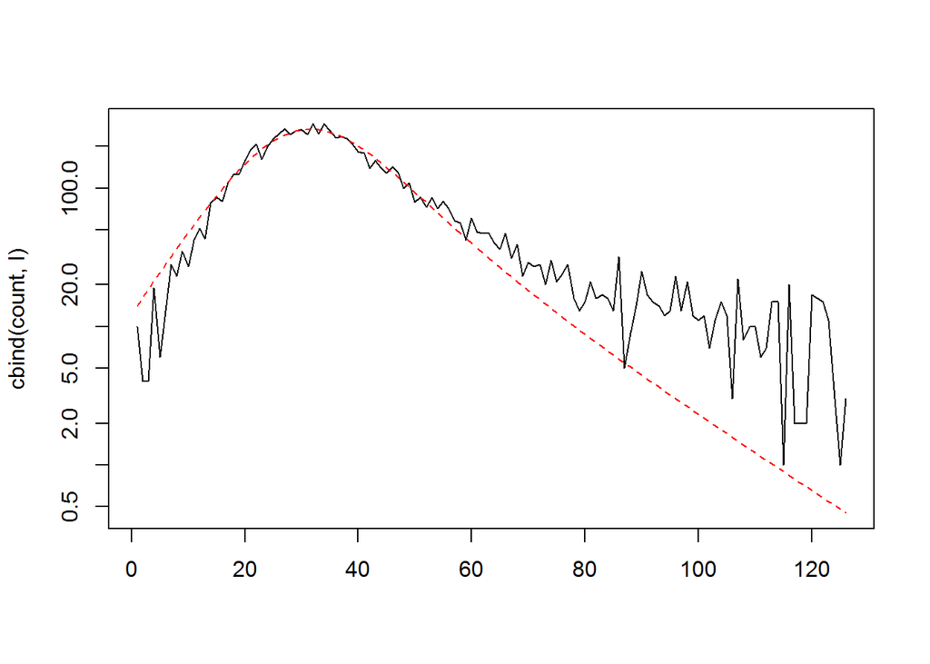

```
##           val     sens_beta    sens_gamma        sens_N       sens_I0
##  5.054110e+02  1.967338e-04 -3.894076e-05  1.227398e-04  4.750764e-05
```

```r
findSens(df.1918, coef(fit.germ2),plot.it = TRUE, incidence = TRUE, log = "y", nll = TRUE)
```

- This fit doesn’t look very good along the tail
- Population size seems pretty bad too

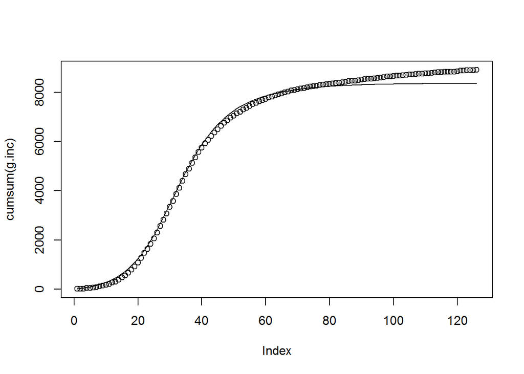

```r
inc <- SIR.detsim(t.germ, trans.pars(coef(fit.germ2)), incidence = TRUE)
plot(cumsum(g.inc))
lines(cumsum(inc))
```